# STAT5003: Final Report

Group W06_G08

2025-11-02

## Problem Overview

In New South Wales, road traffic accidents represent a serious public safety issue. Each year, numerous injuries and fatalities occur, resulting in significant economic losses. Although the government has invested substantial funds in road safety, such as the $2.8 billion committed over the next four years, accidents continue to occur frequently with varying degrees of severity. Sydney’s traffic risks are particularly pronounced due to rapid population growth, traffic congestion, and the complexity of its road system. While many studies have focused on reducing the frequency of accidents, less research has examined the factors influencing accident severity. Therefore, this project aims to explore these contributing factors to provide new insights into how road injuries can be effectively reduced.

The goal of this project is to develop a machine learning model that predicts accident severity using historical crash data and traffic enforcement information. Framed as a multi-class classification problem, the model aims to categorise accidents into five levels of severity: fatal, serious injury, moderate injury, minor injury, and no injury. The model incorporates features such as the time and date of the incident, weather conditions, road type, number of vehicles involved, and distance from speed cameras.

The three primary objectives of this study are to:

1. Investigate the relationship between various factors and accident severity
2. Analyse the impact of vehicle type and the number of vehicles involved on accident outcomes
3. Examine the role of traffic enforcement measures, such as proximity to speed cameras, in determining accident severity

By predicting accident severity, this study aims to enhance public safety and support government decision-making regarding road planning, traffic enforcement, and resource allocation.

First, we will import our libraries and data.

```r
library(readxl)
library(readr)
library(dplyr)
library(purrr)
library(tibble)
library(tidyr)
library(ggplot2)
library(kableExtra)
library(knitr)
library(visdat)
library(patchwork)
library(geosphere)
library(sf)
library(caret)
library(themis)
library(mlbench)
library(recipes)
library(rsample)
library(tidyverse)
library(tidymodels)
library(nnet)
library(e1071)
library(smotefamily)
library(MASS)
library(dplyr)
library(ggplot2)
library(forcats)
library(MVN)
library(GGally)
library(biotools)
library(FactoMineR)
library(factoextra)
library(tidyr)
library(reshape2)
library(ggrepel)
library(mice)

# Import Crash-level data
crash_2019_2023 <- read_excel("nsw_road_crash_data_2019-2023_crash.xlsx")

# Import Speed and red-light camera data
fixed_cameras <- read_excel("nsw-speed-cameras-gps-locations-november-2021.xlsx", sheet = 1)
redlight_cameras <- read_excel("nsw-speed-cameras-gps-locations-november-2021.xlsx", sheet = 2)
# head(crash_2019_2023,1)
```

## Data Description

This study uses two datasets from the NSW Government Transport Open Data Hub to analyse factors influencing traffic accident severity across New South Wales between 2019 and 2023. Together, they capture information on crash characteristics and speed enforcement camera locations, enabling examination of environmental, temporal, and enforcement-related influences on crash outcomes.

The primary dataset, `nsw_road_crash_data_2019–2023_crash.xlsx`, contains 93,492 observations and 50 variables describing each crash. The key variable, Degree of Crash – Detailed, classifies severity into five categories: Non-casualty (towaway), Minor/Other Injury, Moderate Injury, Serious Injury, and Fatal. The dataset also includes crash time, date, location, weather, road type, and vehicle involvement details. These provide a diverse mix of numerical and categorical features for predictive modelling.

The secondary dataset, `nsw-speed-cameras-gps-locations-november-2021.xlsx`, documents the positions of fixed and red-light speed cameras across NSW. The fixed camera sheet covers 103 roads, while the red-light camera sheet covers 201 roads, each including suburb, road name, camera count, and GPS coordinates. Both sheets were merged into a single dataframe, with each camera represented as a distinct record.

To align the datasets, crashes before November 2019 were removed, as installation dates for cameras were unavailable. Each crash was geocoded, and the distance (in km) to the nearest fixed and red-light camera was calculated using spatial analysis (WGS84 system, sf library). These distances were then added as new features to the crash dataset.

Overall pre-processing included creating new variables for camera distance, turning categorical variables into factors, and selecting columns. The code snippets are commented for ease of reading. Additionally, individual models had their own pre-processing.

```r
# Combine the camera datasets together into 1 dataframe
# Columns to standardise
latlong_cols <- c("Lat(1)", "Long(1)", "Lat(2)", "Long(2)", "Lat(3)", "Long(3)")

# redlight cameras start with more columns than fixed cameras
redlight_cameras <- redlight_cameras %>%
  mutate(Camera_type = "Red_Light") %>%
  # Force all Lat/Long columns to numeric
  mutate(across(all_of(latlong_cols), ~ parse_number(as.character(.))))

# Add the missing columns as numeric NAs, then set Camera_type
fixed_cameras <- fixed_cameras %>%
  mutate(
    `Lat(2)`  = NA_real_,
    `Long(2)` = NA_real_,
    `Lat(3)`  = NA_real_,
    `Long(3)` = NA_real_,
    Camera_type = "Fixed"
  ) %>%
  # Ensure all Lat/Long columns exist and are numeric
  mutate(across(all_of(latlong_cols), ~ parse_number(as.character(.))))

# Enforce a consistent column order for ease of use
col_order <- c("SZ?", "SUBURB/TOWN", "ROAD/S", "Cameras",
               "Lat(1)", "Long(1)", "Lat(2)", "Long(2)", "Lat(3)", "Long(3)",
               "Camera_type")

# Bind cameras into one dataset
speed_cameras <- bind_rows(
  redlight_cameras %>% dplyr::select(dplyr::any_of(col_order)),
  fixed_cameras %>% dplyr::select(dplyr::any_of(col_order))
)


# head(speed_cameras)
# Keep only crashes from Nov 2019 onwards
crash_2019_2023_filtered <- crash_2019_2023 %>%
  filter(`Year of crash` > 2019 |
           (`Year of crash` == 2019 & `Month of crash` %in% c("November", "December")))

# Splits cameras with multiple points to individual rows
speed_cam_pts <- speed_cameras %>%
  pivot_longer(
    cols = c(`Lat(1)`, `Long(1)`, `Lat(2)`, `Long(2)`, `Lat(3)`, `Long(3)`),
    names_to = c(".value", "idx"),
    names_pattern = "(Lat|Long)\\((\\d)\\)"
  ) %>%
  filter(!is.na(Lat), !is.na(Long)) %>%
  mutate(Lat = as.numeric(Lat), Long = as.numeric(Long)) %>%
  distinct(Long, Lat, Camera_type, .keep_all = TRUE)  # keep type for splitting

#Applies spatial library to convert coordinates spatial objects
#crs = 4326 sets the coordinate reference system to WGS84 (standard GPS lat/long)
speed_cam_sf <- st_as_sf(speed_cam_pts, coords = c("Long", "Lat"), crs = 4326)
sf::sf_use_s2(TRUE)

crash_df <- crash_2019_2023_filtered
valid_rows <- which(!is.na(crash_df$Longitude) & !is.na(crash_df$Latitude))
invalid_rows <- which(is.na(crash_df$Longitude) | is.na(crash_df$Latitude)) # Not used other than to confirm that no invalid rows exist

crash_sf <- st_as_sf(
  crash_df[valid_rows, ],
  coords = c("Longitude", "Latitude"),
  crs = 4326
)

# Split cameras by type
fixed_sf     <- speed_cam_sf %>% filter(Camera_type == "Fixed")
redlight_sf  <- speed_cam_sf %>% filter(Camera_type == "Red_Light")

# Helper to compute nearest distance (km) to a given camera set, returning a vector
nearest_km_to <- function(crash_pts, cam_pts) {
  if (nrow(cam_pts) == 0) return(rep(NA_real_, nrow(crash_pts)))
  nn_idx <- st_nearest_feature(crash_pts, cam_pts)
  as.numeric(st_distance(crash_pts, cam_pts[nn_idx, ], by_element = TRUE)) / 1000
}

# Distances
nearest_fixed_km    <- nearest_km_to(crash_sf, fixed_sf)
nearest_redlight_km <- nearest_km_to(crash_sf, redlight_sf)

# Write back to the full crash dataframe
crash_df$nearest_fixed_km    <- NA_real_
crash_df$nearest_redlight_km <- NA_real_

crash_df$nearest_fixed_km[valid_rows]    <- nearest_fixed_km
crash_df$nearest_redlight_km[valid_rows] <- nearest_redlight_km

crash_2019_2023_filtered <- crash_df

# head(crash_2019_2023_filtered)

#Remove km/h from Speed limit
crash_data <- crash_2019_2023_filtered %>%
  mutate(
    # remove km/h
    `Speed limit` = gsub("(?i)\\s*km/h", "", `Speed limit`, perl = TRUE),
    # trim spaces
    `Speed limit` = trimws(`Speed limit`),
    # convert to numeric
    `Speed limit` = as.numeric(`Speed limit`)
  )

# Drop non-analysed columns before EDA
crash_model_data <- crash_data %>%
  dplyr::select(
    -`Degree of crash`,
    -`Reporting year`,
    -`Street of crash`,
    -`Primary permanent feature`,
    -`Primary temporary feature`,
    -`Primary hazardous feature`,
    -`Road classification (admin)`,
    -Distance,
    -Direction,
    -`Identifying feature`,
    -`Identifying feature type`
  )

crash_data <- crash_data %>%
  dplyr::select(
    -`Degree of crash`,
    -`Reporting year`,
    -`Street of crash`,
    -`Primary permanent feature`,
    -`Primary temporary feature`,
    -`Primary hazardous feature`,
    -`Road classification (admin)`,
    -Distance,
    -Direction,
    -`Identifying feature`,
    -`Identifying feature type`
  )

# Factorise columns to make graphs more readable
crash_data <- crash_data %>%
  mutate(`Degree of crash - detailed` = factor(
    `Degree of crash - detailed`,
    levels = c("Non-casualty (towaway)","Minor/Other Injury","Moderate Injury","Serious Injury","Fatal"),
    ordered = TRUE
  ))

crash_data <- crash_data %>%
  mutate(`Month of crash` = factor(
    `Month of crash`,
    levels = c("January","February","March","April","May","June","July","August","September","October","November","December"),
    ordered = TRUE
  ))

crash_data <- crash_data %>%
  mutate(`Day of week of crash` = factor(
    `Day of week of crash`,
    levels = c("Monday", "Tuesday", "Wednesday", "Thursday", "Friday", "Saturday", "Sunday"),
    ordered = TRUE
  ))

crash_data <- crash_data %>%
  mutate(`Natural lighting` = factor(
    `Natural lighting`,
    levels = c("Dawn","Daylight","Dusk","Darkness","Unknown"),
    ordered = TRUE
  ))

crash_data <- crash_data %>%
  mutate(`Weather` = factor(
    `Weather`,
    levels = c("Fine","Overcast","Fog or mist","Raining","Snowing","Other","Unknown"),
    ordered = TRUE
  ))

crash_data <- crash_data %>%
  mutate(`Two-hour intervals` = factor(
    `Two-hour intervals`,
    levels =
      c(
        "00:01 - 01:59",  "02:00 - 03:59",
        "04:00 - 05:59",  "06:00 - 07:59",
        "08:00 - 09:59",  "10:00 - 11:59",
        "12:00 - 13:59",  "14:00 - 15:59",
        "16:00 - 17:59",  "18:00 - 19:59",
        "20:00 - 21:59",  "22:00 - Midnight",
        "Unknown"
      ),
    ordered = TRUE
  ))

# Making a function to easily create nice looking tables from columns
style_column <- function(column,name,na="no"){
  df <- table(column,useNA=na) %>% addmargins() %>% as.matrix() %>% t() %>% as.data.frame()
  df <- cbind(c("Crash Frequency"),df)
  names(df)[1] = name
  names(df)[ncol(df)] = "Total"
  df %>%
  kable(format = "html", booktabs = TRUE, align = "c") %>%
  kable_styling(full_width = FALSE, position = "center", bootstrap_options = c("striped", "hover", "condensed", "responsive")) # Responsive allows the table to properly scale with browser size - for example, on phones.
}
```

## Exploratory Data Analysis (EDA)

### Numerical Data

The dataset contains 16 numerical variables, though several serve specific purposes: `Crash ID` is a unique identifier, RUM and DCA codes map to categorical data, and Latitude/Longitude are used for distance calculations. The key numeric features analysed are:

#### Key Findings:

**Injury counts**: Number killed, seriously injured, moderately injured, and minor/other injured are all highly positively skewed discrete variables. Most crashes result in no fatalities.

**Speed Limits**: Crashes are recorded most frequently at 50-60km/h, likely due to these being the most common urban speed limits. However, proportionately more fatal crashes appear to occur on roads with speed limits above 80 km/h. This also appears to be the case at lower speeds of 10-20 km/h, although the lack of data here makes this extremely variable.

**Speed Enforcement**: `nearest_fixed_km` and `nearest_redlight_km` measure crash proximity to speed cameras (ranges: 0-979 km and 0-934 km; medians: 4.5 km and 3.1 km). Both show severe right skewness with most crashes clustered near cameras (>50,000 at 0 km in histograms). A log transformation was used to normalise the distributions for improved model performance. These variables have a high correlation, so multicollinearity is a consideration.

**Click to expand tables/plots**

```r
# Route categorization
crash_data <- crash_data %>%
  mutate(RouteCategory = case_when(
    `Route no.` >= 1    & `Route no.` <= 31    ~ "HW",
    `Route no.` >= 51   & `Route no.` <= 707   ~ "MR",
    `Route no.` >= 2001 & `Route no.` <= 2126  ~ "SR",
    `Route no.` >= 4000 & `Route no.` <= 4058  ~ "TO",
    `Route no.` >= 8001 & `Route no.` <= 8011  ~ "TW",
    `Route no.` >= 7000 & `Route no.` < 8000   ~ "UR",
    `Route no.` >= 6000 & `Route no.` < 6093   ~ "MW",
    is.na(`Route no.`)   ~ "Missing",
    TRUE ~ "Other"
  )) %>%
  mutate(RouteCategory = factor(RouteCategory,
                                levels = c("HW","MR","SR","TO","MW","UR","TW","Other","Missing"),
                                ordered = FALSE))

table(crash_data$RouteCategory,useNA = "ifany")
##
##      HW      MR      SR      TO      MW      UR      TW   Other Missing
##   13319   22973    1725      48    2703    6840      14       0   28575
```

```r
table(crash_data$`No. of traffic units involved`)
##
##     1     2     3     4     5     6     7     8     9    10    11    16    18
## 22733 44937  6618  1439   309    89    34    16     7     7     2     2     1
##    21    26
##     2     1
```

```r
# Printing summaries so they get folded
summary(crash_data$`No. killed`)
##     Min.  1st Qu.   Median     Mean  3rd Qu.     Max.
##  0.00000  0.00000  0.00000  0.01622  0.00000 10.00000
summary(crash_data$`No. seriously injured`)
##    Min. 1st Qu.  Median    Mean 3rd Qu.    Max.
##  0.0000  0.0000  0.0000  0.2277  0.0000 11.0000
summary(crash_data$`No. moderately injured`)
##    Min. 1st Qu.  Median    Mean 3rd Qu.    Max.
##  0.0000  0.0000  0.0000  0.3656  1.0000 10.0000
summary(crash_data$`No. minor-other injured`)
##    Min. 1st Qu.  Median    Mean 3rd Qu.    Max.
##  0.0000  0.0000  0.0000  0.2349  0.0000 48.0000
```

```r
# library(scales)  # for percent_format()

# crash_data %>%
#   filter(!is.na(`Speed limit`), !is.na(`Degree of crash - detailed`)) %>%
#   ggplot(aes(x = factor(`Speed limit`), fill = `Degree of crash - detailed`)) +
#     geom_bar(position = "fill") +
#     labs(
#       x = "Speed Limit (km/h)",
#       y = "Proportion of Crashes",
#       title = "Proportion of Crashes by Speed Limit and Degree of Crash",
#       fill = "Degree of Crash"
#     ) +
#     scale_fill_brewer(palette = 'RdYlGn',direction = -1) +
#     scale_y_continuous(labels = percent_format()) +
#     theme_minimal()

tab <- table(crash_data$`Degree of crash - detailed`,crash_data$`Speed limit`) %>% addmargins()
rownames(tab)[nrow(tab)] <- "Total"
colnames(tab)[ncol(tab)] <- "Total"
kable(tab, format = "html", booktabs = TRUE, caption = "Crashes by Speed Limit and Severity") %>%
  add_header_above(c(" " = 1, "Speed Limit" = ncol(tab)-1, " " = 1)) %>%
  kable_styling(full_width = FALSE, position = "center", bootstrap_options = c("striped", "hover", "condensed", "responsive"))
```

Crashes by Speed Limit and Severity

|  | Speed Limit 10 | Speed Limit 20 | Speed Limit 30 | Speed Limit 40 | Speed Limit 50 | Speed Limit 60 | Speed Limit 70 | Speed Limit 80 | Speed Limit 90 | Speed Limit 100 | Speed Limit 110 | Total |
| --- | --- | --- | --- | --- | --- | --- | --- | --- | --- | --- | --- | --- |
| Non-casualty (towaway) | 11 | 8 | 21 | 840 | 9273 | 6537 | 1953 | 1935 | 318 | 2603 | 1248 | 24747 |
| Minor/Other Injury | 10 | 4 | 50 | 696 | 4026 | 4233 | 1451 | 1141 | 173 | 1040 | 390 | 13214 |
| Moderate Injury | 18 | 11 | 41 | 948 | 7136 | 5900 | 1696 | 2219 | 290 | 2455 | 754 | 21468 |
| Serious Injury | 18 | 9 | 39 | 635 | 4767 | 4082 | 1189 | 1911 | 217 | 2062 | 673 | 15602 |
| Fatal | 1 | 1 | 0 | 23 | 203 | 185 | 79 | 167 | 17 | 378 | 88 | 1142 |
| Total | 58 | 33 | 151 | 3142 | 25405 | 20937 | 6368 | 7373 | 1015 | 8538 | 3153 | 76173 |

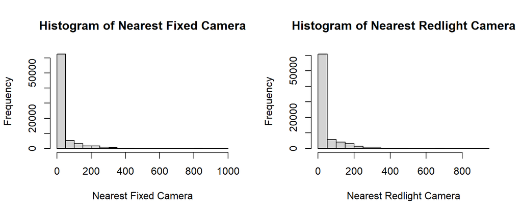

```r
par(mfrow = c(1,2))
hist(crash_data$nearest_fixed_km, main = "Histogram of Nearest Fixed Camera",xlab="Nearest Fixed Camera")
hist(crash_data$nearest_redlight_km, main = "Histogram of Nearest Redlight Camera",xlab="Nearest Redlight Camera")
```

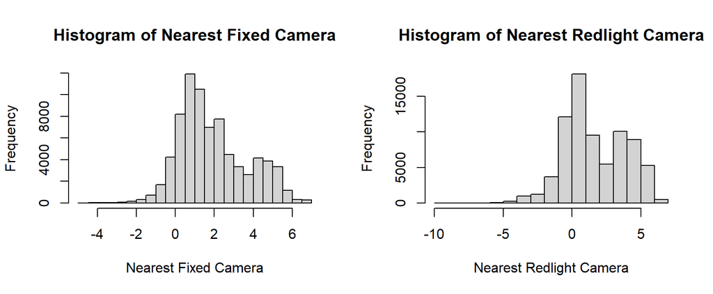

```r
# Log Transformation
crash_data$nearest_fixed_km <- log(crash_data$nearest_fixed_km)
crash_data$nearest_redlight_km <- log(crash_data$nearest_redlight_km)
par(mfrow = c(1,2))
hist(crash_data$nearest_fixed_km, main = "Histogram of Nearest Fixed Camera",xlab="Nearest Fixed Camera")
hist(crash_data$nearest_redlight_km, main = "Histogram of Nearest Redlight Camera",xlab="Nearest Redlight Camera")
```

### Categorical Data

```r
style_column(crash_data$`Degree of crash - detailed`,"Degree of Crash")
```

| Degree of Crash | Non-casualty (towaway) | Minor/Other Injury | Moderate Injury | Serious Injury | Fatal | Total |
| --- | --- | --- | --- | --- | --- | --- |
| Crash Frequency | 24755 | 13219 | 21474 | 15607 | 1142 | 76197 |

#### EDA Key Findings:

**Temporal**: Serious/fatal crashes peak late night (10PM-2AM); April/August/October show highest severe proportions; active school zones show reduced severity.

**Weather/Environment**: Most crashes in fine/daylight conditions, but poor conditions increase fatality risk; areas without street lighting show higher severe crash rates.

**Road characteristics**: Straight roads dominate; crashes on sealed, dry roads most common; urbanisation and road alignment affect severity.

**Traffic controls**: Give-way signs and roundabouts frequent; signal operation impacts outcomes.

**Vehicle involvement**: Rear-end collisions most common; head-on most fatal; motorcycles/pedal cycles highest risk (>50% serious/fatal); passenger cars most frequent but lower severity.

**Click to expand tables/plots**

```r
style_column(crash_data_cat$`Month of crash`,"Month of Crash")
```

| Month of Crash | January | February | March | April | May | June | July | August | September | October | November | December | Total |
| --- | --- | --- | --- | --- | --- | --- | --- | --- | --- | --- | --- | --- | --- |
| Crash Frequency | 5536 | 6000 | 6547 | 5613 | 6687 | 6405 | 5978 | 5803 | 5702 | 6141 | 7990 | 7795 | 76197 |

```r
style_column(crash_data_cat$`Day of week of crash`,"Day of Week of Crash")
```

| Day of Week of Crash | Monday | Tuesday | Wednesday | Thursday | Friday | Saturday | Sunday | Total |
| --- | --- | --- | --- | --- | --- | --- | --- | --- |
| Crash Frequency | 10040 | 10491 | 11183 | 11388 | 12131 | 11352 | 9612 | 76197 |

```r
style_column(crash_data_cat$`Two-hour intervals`,"Two-Hour Intervals")
```

| Two-Hour Intervals | 00:01 - 01:59 | 02:00 - 03:59 | 04:00 - 05:59 | 06:00 - 07:59 | 08:00 - 09:59 | 10:00 - 11:59 | 12:00 - 13:59 | 14:00 - 15:59 | 16:00 - 17:59 | 18:00 - 19:59 | 20:00 - 21:59 | 22:00 - Midnight | Unknown | Total |
| --- | --- | --- | --- | --- | --- | --- | --- | --- | --- | --- | --- | --- | --- | --- |
| Crash Frequency | 2531 | 1882 | 2608 | 5896 | 7759 | 8123 | 8882 | 10659 | 11082 | 7469 | 5193 | 4109 | 4 | 76197 |

```r
crash_data_cat <- crash_data_cat %>%
  mutate(
    `School zone` = ifelse(
      `School zone active` == "Yes",
      "Yes", "No"
    )
  )
table(crash_data_cat$`School zone`,crash_data_cat$`Degree of crash - detailed`) %>%
  kable(format = "html", booktabs = TRUE,
      caption = "Crash Severity in Active School Zone") %>%
  kable_styling(full_width = FALSE, position = "center")
```

Crash Severity in Active School Zone

|  | Non-casualty (towaway) | Minor/Other Injury | Moderate Injury | Serious Injury | Fatal |
| --- | --- | --- | --- | --- | --- |
| No | 24577 | 13063 | 21296 | 15480 | 1140 |
| Yes | 178 | 156 | 178 | 127 | 2 |

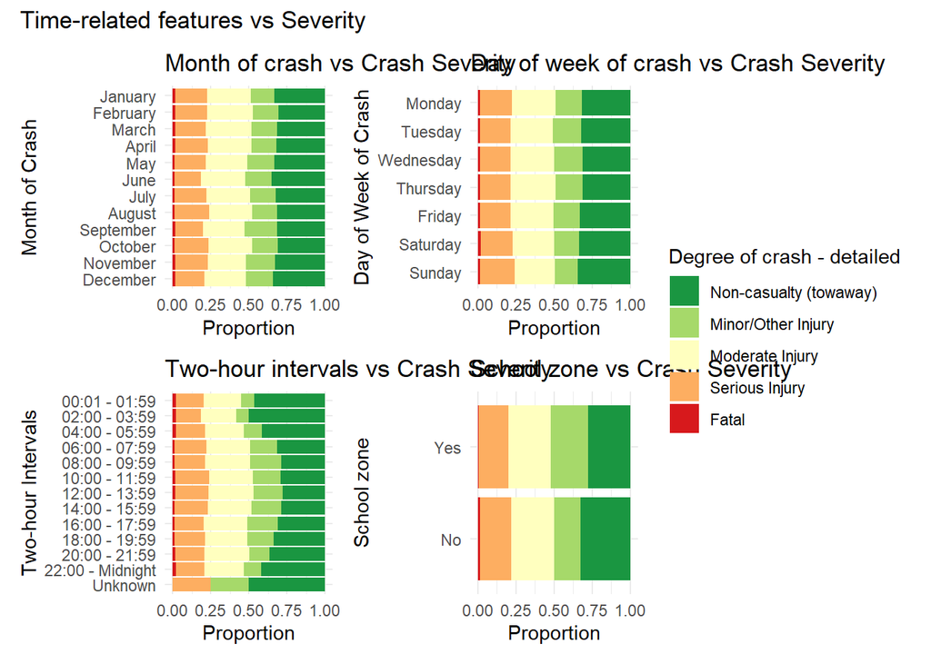

```r
# Month vs target
p_month_of_crash <- ggplot(crash_data_cat, aes(x = forcats::fct_rev(`Month of crash`), fill = `Degree of crash - detailed`)) +
  geom_bar(position = "fill") +
  labs(title = "Month of crash vs Crash Severity", x = "Month of Crash",
       y = "Proportion") +
  theme_minimal() +
  scale_fill_brewer(palette = 'RdYlGn',direction = -1) +
  coord_flip()

# Day of week vs target
p_day_of_week <- ggplot(crash_data_cat, aes(x = forcats::fct_rev(`Day of week of crash`), fill = `Degree of crash - detailed`)) +
  geom_bar(position = "fill") +
  labs(title = "Day of week of crash vs Crash Severity", x = "Day of Week of Crash",
       y = "Proportion") +
  theme_minimal() +
  scale_fill_brewer(palette = 'RdYlGn',direction = -1) +
  coord_flip()

# Time (2h interval) vs target
p_time_two_hour <- ggplot(crash_data_cat, aes(x = forcats::fct_rev(`Two-hour intervals`), fill = `Degree of crash - detailed`)) +
  geom_bar(position = "fill") +
  labs(title = "Two-hour intervals vs Crash Severity", x = "Two-hour Intervals",
       y = "Proportion") +
  theme_minimal() +
  scale_fill_brewer(palette = 'RdYlGn',direction = -1) +
  coord_flip()

# School zone vs Target
p_school_zone <- ggplot(crash_data_cat, aes(x = `School zone`, fill = `Degree of crash - detailed`)) +
  geom_bar(position = "fill") +
  labs(title = "School zone vs Crash Severity",
       y = "Proportion") +
  theme_minimal() +
  scale_fill_brewer(palette = 'RdYlGn',direction = -1) +
  coord_flip()

# plot matrix
time_plots <- list(
  p_month_of_crash,
  p_day_of_week,
  p_time_two_hour,
  p_school_zone
)

p_time_matrix <- wrap_plots(time_plots, ncol = 2) +
  plot_layout(guides = "collect") +
  plot_annotation(title = "Time-related features vs Severity")

p_time_matrix
```

```r
# tables
# Weather
style_column(crash_data_cat$`Weather`,"Weather")
```

| Weather | Fine | Overcast | Fog or mist | Raining | Snowing | Other | Unknown | Total |
| --- | --- | --- | --- | --- | --- | --- | --- | --- |
| Crash Frequency | 59941 | 5148 | 530 | 9395 | 83 | 151 | 949 | 76197 |

```r
# Street lighting
style_column(crash_data_cat$`Street lighting`, "Street lighting")
```

| Street lighting | Nil | Off | On | Unknown / not stated | Total |
| --- | --- | --- | --- | --- | --- |
| Crash Frequency | 19582 | 16549 | 12317 | 27749 | 76197 |

```r
# Natural lighting
tab <- table(crash_data_cat$`Natural lighting`,crash_data_cat$`Degree of crash - detailed`) %>% addmargins()
rownames(tab)[nrow(tab)] <- "Total"
colnames(tab)[ncol(tab)] <- "Total"
kable(tab, format = "html", booktabs = TRUE, caption = "Crashes by Natural Lighting and Severity") %>%
  kable_styling(full_width = FALSE, position = "center")
```

Crashes by Natural Lighting and Severity

|  | Non-casualty (towaway) | Minor/Other Injury | Moderate Injury | Serious Injury | Fatal | Total |
| --- | --- | --- | --- | --- | --- | --- |
| Dawn | 963 | 389 | 677 | 526 | 42 | 2597 |
| Daylight | 14314 | 9426 | 14287 | 10630 | 671 | 49328 |
| Dusk | 1433 | 936 | 1277 | 811 | 64 | 4521 |
| Darkness | 7840 | 2386 | 5185 | 3634 | 365 | 19410 |
| Unknown | 205 | 82 | 48 | 6 | 0 | 341 |
| Total | 24755 | 13219 | 21474 | 15607 | 1142 | 76197 |

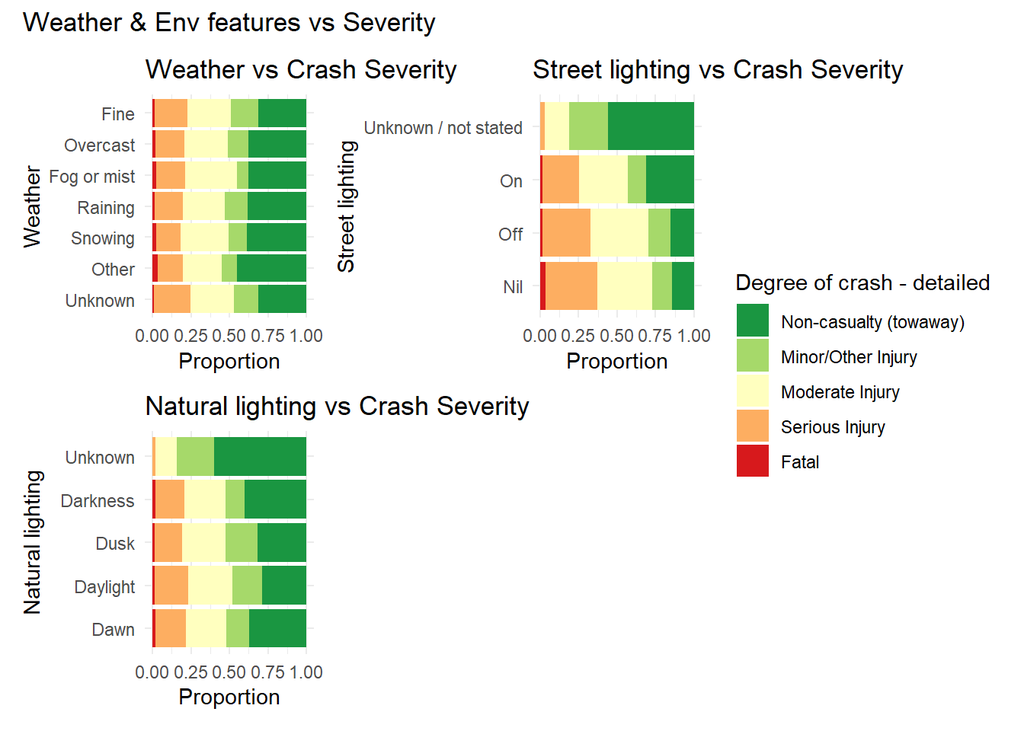

```r
# plots

# Weather vs target
p_weather <- ggplot(crash_data_cat, aes(x = forcats::fct_rev(Weather), fill = `Degree of crash - detailed`)) +
  geom_bar(position = "fill") +
  labs(title = "Weather vs Crash Severity", x = "Weather",
       y = "Proportion") +
  theme_minimal() +
  scale_fill_brewer(palette = 'RdYlGn',direction = -1) +
  coord_flip()

# Street lighting vs target
p_street_lighting <- ggplot(crash_data_cat, aes(x = `Street lighting`, fill = `Degree of crash - detailed`)) +
  geom_bar(position = "fill") +
  labs(title = "Street lighting vs Crash Severity",
       y = "Proportion") +
  theme_minimal() +
  scale_fill_brewer(palette = 'RdYlGn',direction = -1) +
  coord_flip()

# Natural lighting vs target
p_natural_lighting <- ggplot(crash_data_cat, aes(x = `Natural lighting`, fill = `Degree of crash - detailed`)) +
  geom_bar(position = "fill") +
  labs(title = "Natural lighting vs Crash Severity",
       y = "Proportion") +
  theme_minimal() +
  scale_fill_brewer(palette = 'RdYlGn',direction = -1) +
  coord_flip()

# plot matrix
weather_plots <- list(
  p_weather,
  p_street_lighting,
  p_natural_lighting
)

p_weather_matrix <- wrap_plots(weather_plots, ncol = 2) +
  plot_layout(guides = "collect") +
  plot_annotation(title = "Weather & Env features vs Severity")

p_weather_matrix
```

```r
# tables
# street type
street_table <- crash_data_cat %>%
  count(`Street type`, name = "Frequency") %>%
  arrange(desc(Frequency))

street_table %>%
  kable("html", escape = TRUE, col.names = c("Street type", "Frequency")) %>%
  kable_styling(full_width = TRUE, bootstrap_options = c("striped", "hover", "condensed", "responsive")) %>%
  column_spec(1, width = "12em", extra_css = "word-wrap: break-word; white-space: normal;")
```

| Street type | Frequency |
| --- | --- |
| RD | 29081 |
| ST | 15995 |
| HWY | 13788 |
| DR | 4673 |
| AVE | 3794 |
| EXP | 2802 |
| WAY | 1960 |
| PDE | 1017 |
| LANE | 581 |
| MS | 547 |
| CRES | 493 |
| PL | 298 |
| PKWY | 234 |
| BVD | 157 |
| CCT | 137 |
| TCE | 125 |
| CL | 120 |
| DSTR | 99 |
| BYPA | 86 |
| TRL | 60 |
| CT | 34 |
| ESP | 30 |
| TRK | 17 |
| PROM | 16 |
| GR | 15 |
| SQ | 9 |
| DVWY | 8 |
| ROW | 6 |
| CH | 4 |
| WALK | 4 |
| MALL | 2 |
| MEWS | 2 |
| ACCS | 1 |
| CSWY | 1 |
| GDNS | 1 |

```r
# type of location
style_column(crash_data_cat$`Type of location`,"Type of Location")
```

| Type of Location | 1-way street | 2-way undivided | Divided road | Dual freeway | L-junction | Multiple intersection | Other | Roundabout | Single limited access | T-junction | Unknown | X-intersection | Y-junction | Total |
| --- | --- | --- | --- | --- | --- | --- | --- | --- | --- | --- | --- | --- | --- | --- |
| Crash Frequency | 346 | 29760 | 8875 | 3008 | 187 | 76 | 371 | 4217 | 56 | 17894 | 8 | 11312 | 87 | 76197 |

```r
# urbanisation
style_column(crash_data_cat$`Urbanisation`,"Urbanisation")
```

| Urbanisation | Country non-urban | Country unknown | Country urban | Newcastle met. area | Sydney metro. area | Wollongong met. area | Total |
| --- | --- | --- | --- | --- | --- | --- | --- |
| Crash Frequency | 10279 | 21 | 19837 | 3718 | 39890 | 2452 | 76197 |

```r
# road alignment
style_column(crash_data_cat$`Alignment`,"Road Alignment")
```

| Road Alignment | Curved | Straight | Total |
| --- | --- | --- | --- |
| Crash Frequency | 17554 | 58643 | 76197 |

```r
# road surface type
style_column(crash_data_cat$`Road surface`,"Road Surface Type")
```

| Road Surface Type | Sealed | Unknown | Unsealed | Total |
| --- | --- | --- | --- | --- |
| Crash Frequency | 74194 | 62 | 1941 | 76197 |

```r
# road surface condition
style_column(crash_data_cat$`Surface condition`,"Road Surface Condition")
```

| Road Surface Condition | Dry | Snow or ice | Unknown | Wet | Total |
| --- | --- | --- | --- | --- | --- |
| Crash Frequency | 61796 | 135 | 494 | 13772 | 76197 |

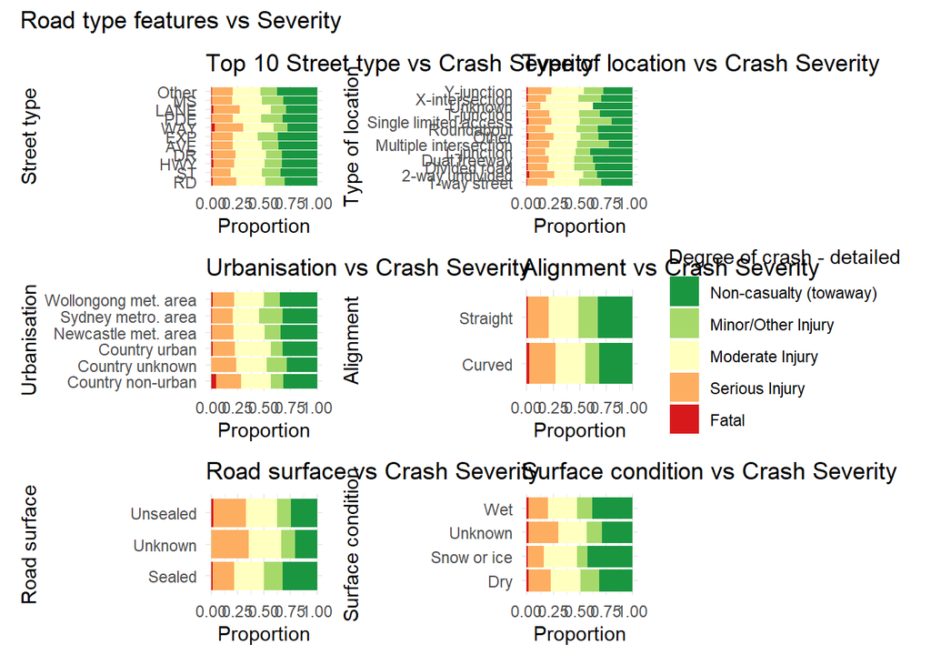

```r
# Keep the top 10 values, group the rest to "Other"
lump_top_n <- function(x, n = 10, other_level = "Other") {
  # Tabulate frequencies
  freq <- sort(table(x), decreasing = TRUE)
  top_levels <- names(freq)[seq_len(min(n, length(freq)))]

  # Replace non-top with "Other"
  x_new <- ifelse(x %in% top_levels, as.character(x), other_level)

  factor(x_new, levels = c(top_levels, other_level))
}

# plots
# Street type vs target
p_street_type <- ggplot(crash_data_cat %>%
         mutate(`Street type` = lump_top_n(`Street type`, n = 10)),
       aes(x = `Street type`, fill = `Degree of crash - detailed`)) +
  geom_bar(position = "fill") +
  labs(title = "Top 10 Street type vs Crash Severity",
       y = "Proportion") +
  theme_minimal() +
  scale_fill_brewer(palette = 'RdYlGn',direction = -1) +
  coord_flip()


# Type of location vs target
p_type_of_location <- ggplot(crash_data_cat, aes(x = `Type of location`, fill = `Degree of crash - detailed`)) +
  geom_bar(position = "fill") +
  labs(title = "Type of location vs Crash Severity",
       y = "Proportion") +
  theme_minimal() +
  scale_fill_brewer(palette = 'RdYlGn',direction = -1) +
  coord_flip()

# Urbanisation vs target
p_urbanisation <- ggplot(crash_data_cat, aes(x = `Urbanisation`, fill = `Degree of crash - detailed`)) +
  geom_bar(position = "fill") +
  labs(title = "Urbanisation vs Crash Severity",
       y = "Proportion") +
  theme_minimal() +
  scale_fill_brewer(palette = 'RdYlGn',direction = -1) +
  coord_flip()

# Alignment vs target
p_alignment <- ggplot(crash_data_cat, aes(x = `Alignment`, fill = `Degree of crash - detailed`)) +
  geom_bar(position = "fill") +
  labs(title = "Alignment vs Crash Severity",
       y = "Proportion") +
  theme_minimal() +
  scale_fill_brewer(palette = 'RdYlGn',direction = -1) +
  coord_flip()

# Road surface vs target
p_surface <- ggplot(crash_data_cat, aes(x = `Road surface`, fill = `Degree of crash - detailed`)) +
  geom_bar(position = "fill") +
  labs(title = "Road surface vs Crash Severity",
       y = "Proportion") +
  theme_minimal() +
  scale_fill_brewer(palette = 'RdYlGn',direction = -1) +
  coord_flip()

# Surface condition vs target
p_surface_condition <- ggplot(crash_data_cat, aes(x = `Surface condition`, fill = `Degree of crash - detailed`)) +
  geom_bar(position = "fill") +
  labs(title = "Surface condition vs Crash Severity",
       y = "Proportion") +
  theme_minimal() +
  scale_fill_brewer(palette = 'RdYlGn',direction = -1) +
  coord_flip()

# plot matrix
road_plots <- list(
  p_street_type,
  p_type_of_location,
  p_urbanisation,
  p_alignment,
  p_surface,
  p_surface_condition
)

p_road_matrix <- wrap_plots(road_plots, ncol = 2) +
  plot_layout(guides = "collect") +
  plot_annotation(title = "Road type features vs Severity")

p_road_matrix
```

```r
# tables
# Signal operation
style_column(crash_data_cat$`Signals operation`,"Signal Operation")
```

| Signal Operation | Nil | Off | On | Unknown / not stated | Total |
| --- | --- | --- | --- | --- | --- |
| Crash Frequency | 64094 | 383 | 11130 | 590 | 76197 |

```r
# Other traffic control
traffic_control_table <- crash_data_cat %>%
  count(`Other traffic control`, name = "Frequency") %>%
  arrange(desc(Frequency))

traffic_control_table %>%
  kable("html", escape = TRUE, col.names = c("Other traffic control", "Frequency")) %>%
  kable_styling(full_width = TRUE, bootstrap_options = c("striped", "hover", "condensed", "responsive")) %>%
  column_spec(1, width = "12em", extra_css = "word-wrap: break-word; white-space: normal;")
```

| Other traffic control | Frequency |
| --- | --- |
| No traffic controls | 60135 |
| Give way sign | 10484 |
| Stop sign | 2914 |
| Ped crossing | 1857 |
| Other traf. control | 225 |
| No right turn | 224 |
| Left turn only | 120 |
| Road/rail worker | 61 |
| No U turn | 35 |
| Rail X stop sign | 29 |
| Rail X flashing sigs | 28 |
| No entry/wrong way | 27 |
| No left turn | 19 |
| Unknown | 19 |
| Police | 13 |
| Rail X no sign | 4 |
| Left turn on red | 3 |

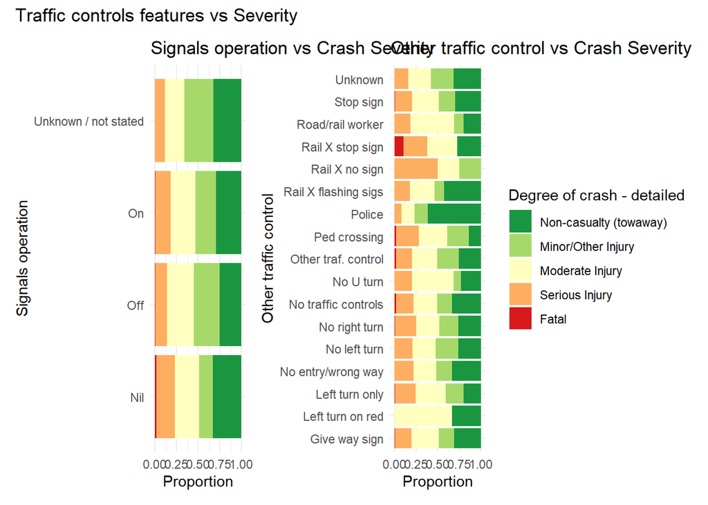

```r
# plots
# Signals operation vs target
p_signals <- ggplot(crash_data_cat, aes(x = `Signals operation`, fill = `Degree of crash - detailed`)) +
  geom_bar(position = "fill") +
  labs(title = "Signals operation vs Crash Severity",
       y = "Proportion") +
  theme_minimal() +
  scale_fill_brewer(palette = 'RdYlGn',direction = -1) +
  coord_flip()

# Other traffic control vs target
p_control <- ggplot(crash_data_cat, aes(x = `Other traffic control`, fill = `Degree of crash - detailed`)) +
  geom_bar(position = "fill") +
  labs(title = "Other traffic control vs Crash Severity",
       y = "Proportion") +
  theme_minimal() +
  scale_fill_brewer(palette = 'RdYlGn',direction = -1) +
  coord_flip()

# plot matrix
controls_plots <- list(
  p_signals,
  p_control
)

p_controls_matrix <- wrap_plots(controls_plots, ncol = 2) +
  plot_layout(guides = "collect") +
  plot_annotation(title = "Traffic controls features vs Severity")

p_controls_matrix
```